# SVAR Application

Aru Bhardwaj

7/26/2020

## Introduction

[Blanchard & Quah (1989)](https://uh.edu/~bsorense/BlanchardQuah1989.pdf) developed an interesting framework for interpreting the Structural Vector Autoregression models. Using the `vars` package in R, here I replicate the codes from the Blog post, [Eloriaga (2020)](https://levelup.gitconnected.com/structural-vector-autoregression-in-r-5d6dbfc56499), to study it from the framework developed by Blanchard and Quah (1989). Thanks to the available information on the blog, through which I got the access to data used in the post. However, the blog post was only for an introduction to SVARs, extending it to further, I used Blanchard & Quah (1989) type SVAR here.

Note: Data used here was available through the Google drive on the Blog post.

At first, the needed packages to do this are `vars`, `tseries`, `svars` and `TSstudio`.

## Converting Data in the Time Series

The following commands are necessay for converting the data in the time series. The plot of out time series data is:

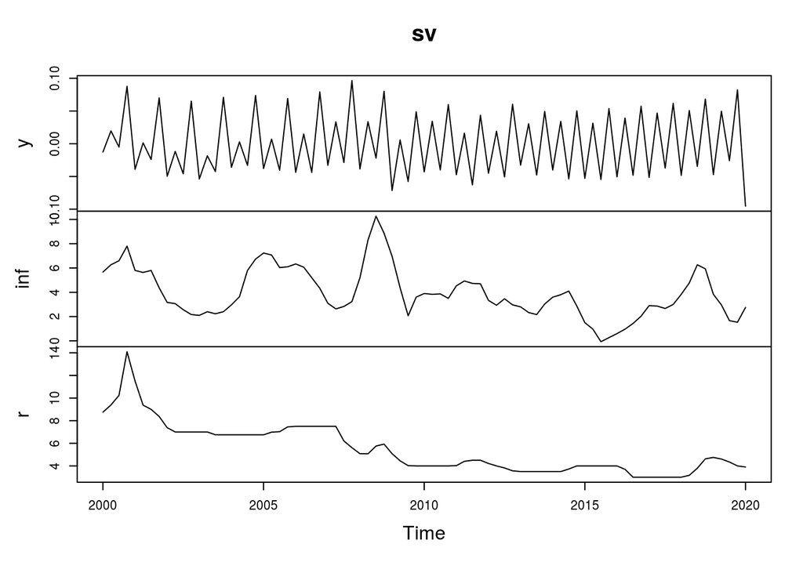

```r
y <- ts(data$Output.Gap, start = c(2000, 1, 1), frequency = 4)
inf<- ts(data$CPI, start = c(2000, 1, 1), frequency = 4)
r <- ts(data$RRP, start = c(2000,1,1), frequency =4)
sv <- cbind(y, inf, r)

plot.ts(sv)
```

**Please note:** `y` is Output Gap, `inf` is Inflation Rate and `r` is Overnight Reverse Repurchase Rate.

## Determine the number of lags

For determining the number of labs, for our VAR model, we’d require the lag value, which, in this case, is **5**.

```r
lagselect <- VARselect(sv, lag.max = 8, type = "both")
lagselect$selection
```

```
## AIC(n)  HQ(n)  SC(n) FPE(n)
##      5      5      5      5
```

## Vector Autoregression Model

The following model will give us the VAR results.

```r
VARmodel <- VAR(sv, lag.max = 5, type = 'const', season = NULL, exogen = NULL)
summary(VARmodel)
```

```
##
## VAR Estimation Results:
## =========================
## Endogenous variables: y, inf, r
## Deterministic variables: const
## Sample size: 76
## Log Likelihood: 178.723
## Roots of the characteristic polynomial:
## 1.007 0.9827 0.9827 0.932 0.8752 0.8752 0.842 0.842 0.8097 0.6856 0.6856 0.5248 0.5248 0.5104 0.5104
## Call:
## VAR(y = sv, type = "const", exogen = NULL, lag.max = 5)
##
##
## Estimation results for equation y:
## ==================================
## y = y.l1 + inf.l1 + r.l1 + y.l2 + inf.l2 + r.l2 + y.l3 + inf.l3 + r.l3 + y.l4 + inf.l4 + r.l4 + y.l5 + inf.l5 + r.l5 + const
##
##          Estimate Std. Error t value Pr(>|t|)
## y.l1    0.5376663  0.1191626   4.512 3.05e-05 ***
## inf.l1  0.0052511  0.0017871   2.938 0.004678 **
## r.l1   -0.0014419  0.0040980  -0.352 0.726180
## y.l2   -0.1374214  0.0634059  -2.167 0.034189 *
## inf.l2 -0.0066139  0.0030753  -2.151 0.035542 *
## r.l2    0.0053350  0.0045335   1.177 0.243925
## y.l3   -0.2271644  0.0623712  -3.642 0.000565 ***
## inf.l3 -0.0009999  0.0032859  -0.304 0.761959
## r.l3   -0.0020080  0.0037063  -0.542 0.589967
## y.l4    0.8160722  0.0618938  13.185  < 2e-16 ***
## inf.l4  0.0049103  0.0030328   1.619 0.110675
## r.l4   -0.0029417  0.0035862  -0.820 0.415293
## y.l5   -0.6744188  0.1240595  -5.436 1.05e-06 ***
## inf.l5 -0.0018283  0.0017707  -1.032 0.305988
## r.l5    0.0014101  0.0022459   0.628 0.532480
## const  -0.0046844  0.0044874  -1.044 0.300724
## ---
## Signif. codes:  0 '***' 0.001 '**' 0.01 '*' 0.05 '.' 0.1 ' ' 1
##
##
## Residual standard error: 0.01057 on 60 degrees of freedom
## Multiple R-Squared: 0.9637,  Adjusted R-squared: 0.9546
```

[output cut: 60 more lines]

```
## F-statistic: 218.5 on 15 and 60 DF,  p-value: < 2.2e-16
##
##
##
## Covariance matrix of residuals:
##              y      inf          r
## y    0.0001118 -0.00114 -0.0003271
## inf -0.0011396  0.58128  0.0644432
## r   -0.0003271  0.06444  0.0655869
##
## Correlation matrix of residuals:
##           y     inf       r
## y    1.0000 -0.1414 -0.1208
## inf -0.1414  1.0000  0.3300
## r   -0.1208  0.3300  1.0000
```

## Blanchard and Quah (1989) type SVAR model

Once we have our VAR model, we can pue `BQ()` function for estimating the Blanchard & Quah (1989) type SVAR results. Which, in this case, are as follows:

```r
BQ<-BQ(VARmodel)
summary(BQ)
```

```
##
## SVAR Estimation Results:
## ========================
##
## Call:
## BQ(x = VARmodel)
##
## Type: Blanchard-Quah
## Sample size: 76
## Log Likelihood: 151.775
##
## Estimated contemporaneous impact matrix:
##            y       inf        r
## y   0.009438 -0.004334 -0.00198
## inf 0.225073  0.726022  0.05930
## r   0.042507  0.055460  0.24638
##
## Estimated identified long run impact matrix:
##           y   inf     r
## y   0.01828 0.000 0.000
## inf 3.62684 4.045 0.000
## r   1.34765 4.028 5.603
##
## Covariance matrix of reduced form residuals (*100):
##            y    inf        r
## y    0.01118 -0.114 -0.03271
## inf -0.11396 58.128  6.44432
## r   -0.03271  6.444  6.55869
```

```r
BQ
```

```
##
## SVAR Estimation Results:
## ========================
##
##
## Estimated contemporaneous impact matrix:
##            y       inf        r
## y   0.009438 -0.004334 -0.00198
## inf 0.225073  0.726022  0.05930
## r   0.042507  0.055460  0.24638
##
## Estimated identified long run impact matrix:
##           y   inf     r
## y   0.01828 0.000 0.000
## inf 3.62684 4.045 0.000
## r   1.34765 4.028 5.603
```

## Impulse Response Functions and the Forecast Error Variance Decompositions

### IRF

This is the most important step in our model, because in this step we seek the results which we need to use. For estimating the Impulsive Response Function, I use use `irf()` function and plot it accordingly.

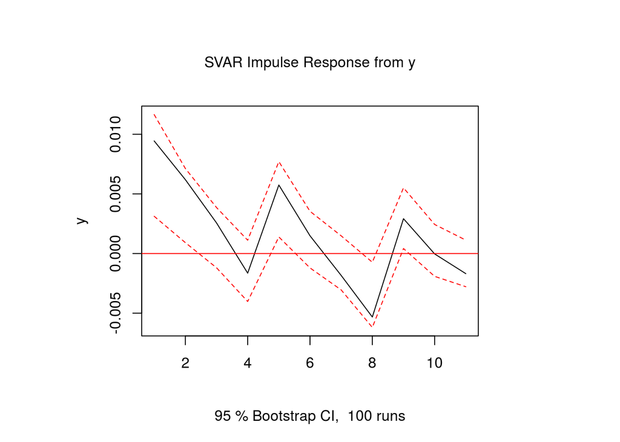

```r
irf1 <- irf(BQ, impulse = 'y', response = 'y')
plot(irf1)
```

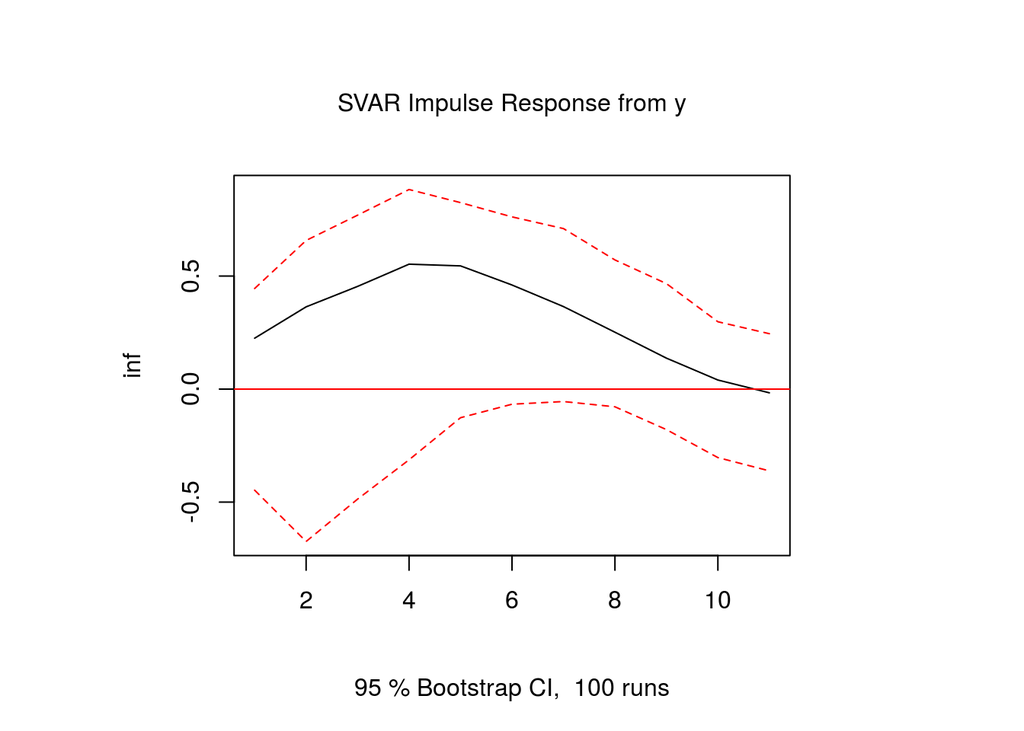

```r
irf2 <- irf(BQ, impulse = 'y', response = 'inf')
plot(irf2)
```

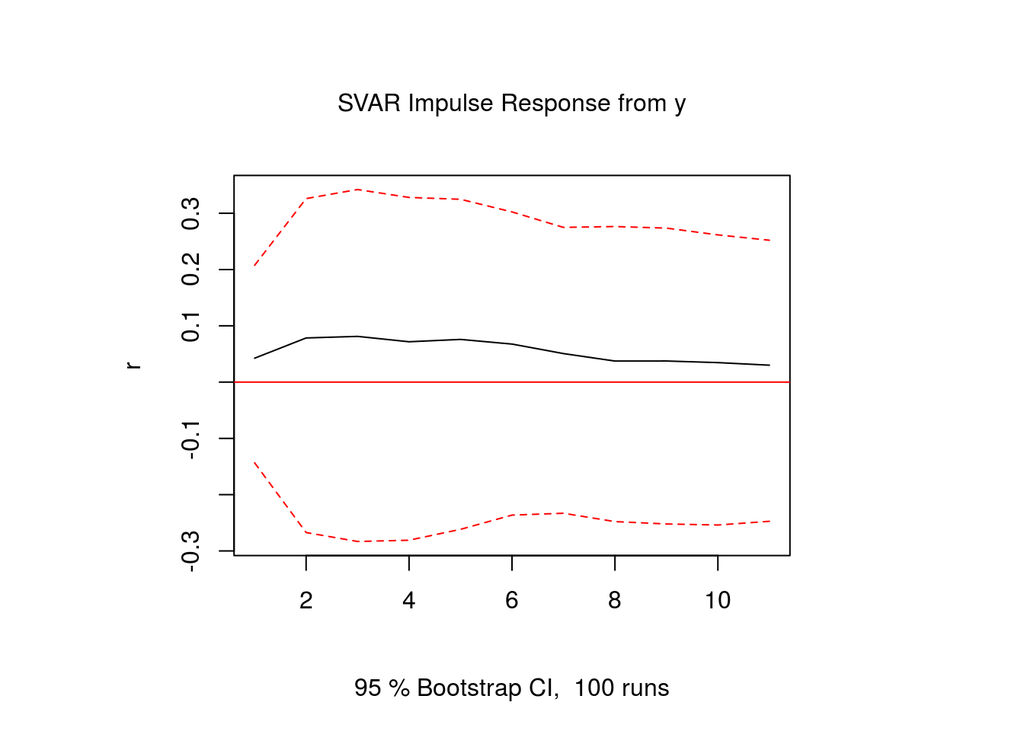

```r
irf3 <- irf(BQ, impulse = 'y', response = 'r')
plot(irf3)
```

### Forcasting and FEVD

Here, I forcast the values of 20 further quarters.

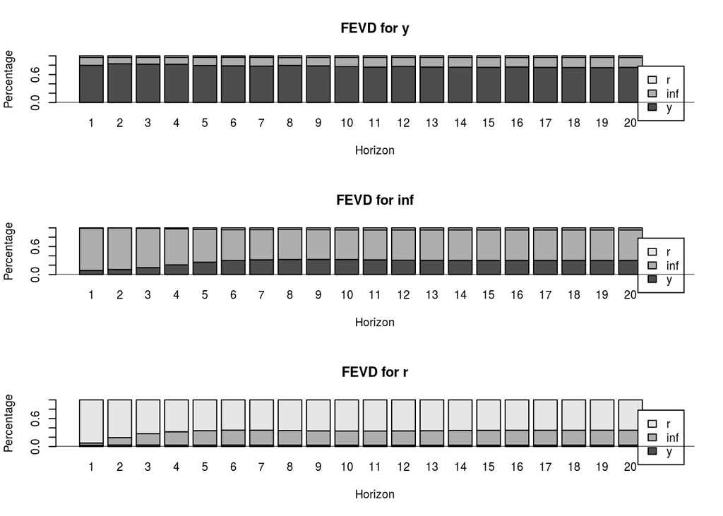

```r
fevd <- fevd(BQ, n.ahead = 20)
plot(fevd)
```

## References

Blanchard, Olivier Jean & Quah, Danny, 1989. [The Dynamic Effects of Aggregate Demand and Supply Disturbances](https://uh.edu/~bsorense/BlanchardQuah1989.pdf), American Economic Review, American Economic Association. (Last accessed: 26 July, 2020)

Eloriga, Justin, 2020. [Introduction to the Structural Vector Autoregression](https://levelup.gitconnected.com/structural-vector-autoregression-in-r-5d6dbfc56499), Level Up Coding by Gitconnected. (Last accessed: 26 July, 2020)